# Modeltime -Feature Engineering-

UPDATE: 2022-12-28 10:08:47

# はじめに

`modeltime`パッケージを使いながら時系列データの予測を行なうノートをいくつかに分けてまとめている。`modeltime`パッケージの目的は、時系列モデルの構築を効率よく行うためのパッケージで、`tidymodels`パッケージと組み合わせて時系列モデルを作成する際に使用される。時系列予測のための体系的なワークフローを提供し、時系列ブーストモデルなど新しいアルゴリズムもカバーしている点が特徴的。モデルの数理的な側面や機械学習の用語などは、このノートでは扱わない。

## 特徴量エンジニアリング

このノートでは、時系列データの特徴量エンジニアリングについてまとめる。ここでは`timetk`パッケージを使って特徴量エンジニアリングを行なう。必要なパッケージを読み込んでおく。

```r
library(tidyverse)
library(timetk)
library(tsibble)
library(tsibbledata)
library(fastDummies)
```

## 使用データ

オーストラリアの小売の売上データセット(`tsibbledata::aus_retail`)を利用する。データの各時系列は下記のキーで一意に識別される。

- `State`: オーストラリアの州
- `Industry`: 業種

ここでは`Australian Capital Territory`の州と5つの業種の値のみに注目する。

```r
tsibbledata::aus_retail %>%
  filter(State == "Australian Capital Territory") %>%
  distinct(State, Industry)
```

```
## # A tibble: 20 × 2
##    State                        Industry
##    <chr>                        <chr>
##  1 Australian Capital Territory Cafes, restaurants and catering services
##  2 Australian Capital Territory Cafes, restaurants and takeaway food services
##  3 Australian Capital Territory Clothing retailing
##  4 Australian Capital Territory Clothing, footwear and personal accessory retai…
##  5 Australian Capital Territory Department stores
##  6 Australian Capital Territory Electrical and electronic goods retailing
##  7 Australian Capital Territory Food retailing
##  8 Australian Capital Territory Footwear and other personal accessory retailing
##  9 Australian Capital Territory Furniture, floor coverings, houseware and texti…
## 10 Australian Capital Territory Hardware, building and garden supplies retailing
## 11 Australian Capital Territory Household goods retailing
## 12 Australian Capital Territory Liquor retailing
## 13 Australian Capital Territory Newspaper and book retailing
## 14 Australian Capital Territory Other recreational goods retailing
## 15 Australian Capital Territory Other retailing
## 16 Australian Capital Territory Other retailing n.e.c.
## 17 Australian Capital Territory Other specialised food retailing
## 18 Australian Capital Territory Pharmaceutical, cosmetic and toiletry goods ret…
## 19 Australian Capital Territory Supermarket and grocery stores
## 20 Australian Capital Territory Takeaway food services
```

`tsibble`クラスなので、通常のデータフレームに変換しておく。

```r
Industries <- c(
  "Cafes, restaurants and catering services",
  "Clothing retailing",
  "Clothing, footwear and personal accessory retailing",
  "Department stores",
  "Electrical and electronic goods retailing"
)

monthly_retail_tbl <- tsibbledata::aus_retail %>%
  tk_tbl() %>%
  filter(State == "Australian Capital Territory") %>%
  filter(Industry %in% Industries) %>%
  mutate(Month = as.Date(Month)) %>%
  mutate(Industry = as_factor(Industry)) %>%
  select(Month, Industry, Turnover)

monthly_retail_tbl %>%
  distinct(Industry)
```

```
## # A tibble: 5 × 1
##   Industry
##   <fct>
## 1 Cafes, restaurants and catering services
## 2 Clothing retailing
## 3 Clothing, footwear and personal accessory retailing
## 4 Department stores
## 5 Electrical and electronic goods retailing
```

使用するデータは最終的に下記の通り。

```r
monthly_retail_tbl %>%
  group_by(Industry) %>%
  summarise(
    min_date = min(Month),
    max_date = max(Month),
    cnt = n()
  )
```

```
## # A tibble: 5 × 4
##   Industry                                           min_date   max_date     cnt
##   <fct>                                              <date>     <date>     <int>
## 1 Cafes, restaurants and catering services           1982-04-01 2018-12-01   441
## 2 Clothing retailing                                 1982-04-01 2018-12-01   441
## 3 Clothing, footwear and personal accessory retaili… 1982-04-01 2018-12-01   441
## 4 Department stores                                  1982-04-01 2018-12-01   441
## 5 Electrical and electronic goods retailing          1982-04-01 2018-12-01   441
```

## 時系列の可視化

5つの業種の時系列を可視化しておく。基本的には上昇トレンドではあるが、各系列ごとに異なる特徴があ見られる。

```r
monthly_retail_tbl %>%
  group_by(Industry) %>%
  plot_time_series(
    Month,
    Turnover,
    .facet_ncol  = 3,
    .smooth      = FALSE,
    .interactive = TRUE
  )
```

[interactive chart not shown]

各系列の月、四半期、年の特徴を可視化する。`Department stores`に焦点を当てる。`tk_seasonal_diagnostics`関数で、系列の月、四半期、年ごとの特徴を計算できる。

```r
monthly_retail_tbl %>%
  filter(Industry == Industries[4]) %>%
  tk_seasonal_diagnostics(.date_var = Month,
                          .value = Turnover)
```

```
## # A tibble: 441 × 5
##    Month      .value month.lbl quarter year
##    <date>      <dbl> <fct>     <fct>   <fct>
##  1 1982-04-01   10.3 April     2       1982
##  2 1982-05-01   10.6 May       2       1982
##  3 1982-06-01    9.9 June      2       1982
##  4 1982-07-01    8.8 July      3       1982
##  5 1982-08-01    8.8 August    3       1982
##  6 1982-09-01    9.2 September 3       1982
##  7 1982-10-01    9.7 October   4       1982
##  8 1982-11-01   11.3 November  4       1982
##  9 1982-12-01   18.5 December  4       1982
## 10 1983-01-01    7.4 January   1       1983
## # … with 431 more rows
```

時系列プロットの激しいスパイクは12月に発生していることがわかる。

```r
monthly_retail_tbl %>%
  filter(Industry == Industries[4]) %>%
  plot_seasonal_diagnostics(.date_var = Month,
                          .value = Turnover,
                          .title = Industries[4])
```

[interactive chart not shown]

## 特徴量エンジニアリング

### 探索的特徴選択

有効な特徴量かどうかは、線形回帰を実行して、調整済R2乗値`Adjusted R-squared`が増加するかを調べればよい。手っ取り早い方法。`Adjusted R-squared`は0.8637。

```r
monthly_retail_tbl %>%
  filter(Industry == Industries[[1]]) %>%
  plot_time_series_regression(
    .date_var = Month,
    .formula = Turnover ~ Month,
    .show_summary = TRUE,
    .title = Industries[1]
  )
```

```
##
## Call:
## stats::lm(formula = .formula, data = df)
##
## Residuals:
##      Min       1Q   Median       3Q      Max
## -14.7358  -2.5295   0.5654   2.5335  16.2649
##
## Coefficients:
##               Estimate Std. Error t value Pr(>|t|)
## (Intercept) -1.115e+01  6.247e-01  -17.86   <2e-16 ***
## Month        2.790e-03  5.284e-05   52.81   <2e-16 ***
## ---
## Signif. codes:  0 '***' 0.001 '**' 0.01 '*' 0.05 '.' 0.1 ' ' 1
##
## Residual standard error: 4.299 on 439 degrees of freedom
## Multiple R-squared:  0.864,  Adjusted R-squared:  0.8637
## F-statistic:  2789 on 1 and 439 DF,  p-value: < 2.2e-16
```

[interactive chart not shown]

### 対数・標準化変換

分散を小さくするために対数変換を利用できる。また、標準化も利用される。

```r
monthly_retail_tbl %>%
  filter(Industry == Industries[[1]]) %>%
  mutate(Turnover =  log1p(x = Turnover)) %>%
  mutate(Turnover =  standardize_vec(Turnover)) %>%
  plot_time_series(
    Month,
    Turnover,
    .facet_ncol  = 3,
    .smooth      = FALSE,
    .interactive = TRUE
  )
```

[interactive chart not shown]

### カレンダーベースの特徴量

`Time Series Signature`とも呼ばれ、`timetk::tk_augment_timeseries_signature()`関数でデータセットに25以上の特徴量を追加できる。

```r
monthly_retail_tbl %>%
  filter(Industry == Industries[[1]]) %>%
  mutate(Turnover =  log1p(x = Turnover)) %>%
  mutate(Turnover =  standardize_vec(Turnover)) %>%
  tk_augment_timeseries_signature(.date_var = Month)
```

```
## # A tibble: 441 × 31
##    Month      Industry Turno…¹ index…²    diff  year year.…³  half quarter month
##    <date>     <fct>      <dbl>   <dbl>   <dbl> <int>   <int> <int>   <int> <int>
##  1 1982-04-01 Cafes, …   -2.01  3.86e8      NA  1982    1982     1       2     4
##  2 1982-05-01 Cafes, …   -2.36  3.89e8 2592000  1982    1982     1       2     5
##  3 1982-06-01 Cafes, …   -2.28  3.92e8 2678400  1982    1982     1       2     6
##  4 1982-07-01 Cafes, …   -2.14  3.94e8 2592000  1982    1982     2       3     7
##  5 1982-08-01 Cafes, …   -2.28  3.97e8 2678400  1982    1982     2       3     8
##  6 1982-09-01 Cafes, …   -2.07  4.00e8 2678400  1982    1982     2       3     9
##  7 1982-10-01 Cafes, …   -1.89  4.02e8 2592000  1982    1982     2       4    10
##  8 1982-11-01 Cafes, …   -1.73  4.05e8 2678400  1982    1982     2       4    11
##  9 1982-12-01 Cafes, …   -1.37  4.08e8 2592000  1982    1982     2       4    12
## 10 1983-01-01 Cafes, …   -2.21  4.10e8 2678400  1983    1982     1       1     1
## # … with 431 more rows, 21 more variables: month.xts <int>, month.lbl <ord>,
## #   day <int>, hour <int>, minute <int>, second <int>, hour12 <int>,
## #   am.pm <int>, wday <int>, wday.xts <int>, wday.lbl <ord>, mday <int>,
## #   qday <int>, yday <int>, mweek <int>, week <int>, week.iso <int>,
## #   week2 <int>, week3 <int>, week4 <int>, mday7 <int>, and abbreviated
## #   variable names ¹Turnover, ²index.num, ³year.iso
```

- `index.num`: “1970-01-01 00:00:00”からの秒数
- `diff`: 直前のレコードのindex.numとの差
- `year`: 年成分
- `year.iso`: ISO年成分。ISOカレンダーは、週の始まりを月曜日とし、1月4日が含まれる週をその年の第1週するカレンダー。
- `half`: 1月から6月が1、7月から12月が2
- `quarter`: 四半期成分
- `month`: 月成分
- `month.xts`: xtsパッケージの実装
- `month.lbl`: 月成分のラベル。
- `day`: 日成分
- `hour`: 時間成分
- `minute`: 分成分
- `second`: 秒成分
- `hour12`: 12時間スケールでの時間成分
- `am.pm`: 午前(AM)=1、午後(PM)=2
- `wday`: 日曜日=1、土曜日=7の曜日成分
- `wday.xts`: xtsパッケージの実装。日曜日は0、土曜日は6の曜日成分
- `wday.lbl`: 日曜日から始まり土曜日で終わる順序付き因子としての曜日成分
- `mday`: その年の日成分(1~366)
- `qday`: その年の四半期基準での日成分(1四半期で1~90という感じ)
- `yday`: その年の日成分(1~366)
- `mweek`: その年の週成分(1-52)
- `week`: その年の週番号(日曜始まり1-52)。
- `week.iso`: その年のISO週番号(月曜始まり1-52)。
- `week2`: ？(隔週での頻度に対する係数)
- `week3`: ？(3週間ごとの頻度に対する係数)
- `week4`: ？(4週に一度の頻度に対する係数。1月から4月は1、5月から8月は2、9月から12月は3)
- `mday7`: ？(その月の曜日の7分割の整数値で、その日がその月に出現した最初の、2番目の、3番目の、…例を返す。例えば、その月の最初の土曜日は mday7 = 1 となる。2番目はmday7 = 2)

系列に合わせて不要なカラムは削除する。

```r
monthly_retail_tbl %>%
  filter(Industry == Industries[[1]]) %>%
  mutate(Turnover =  log1p(x = Turnover)) %>%
  mutate(Turnover =  standardize_vec(Turnover)) %>%
  tk_augment_timeseries_signature(.date_var = Month) %>%
  select(-diff, -matches("(.xts$)|(.iso$)|(hour)|(minute)|(second)|(day)|(week)|(am.pm)"))
```

```
## # A tibble: 441 × 9
##    Month      Industry         Turno…¹ index…²  year  half quarter month month…³
##    <date>     <fct>              <dbl>   <dbl> <int> <int>   <int> <int> <ord>
##  1 1982-04-01 Cafes, restaura…   -2.01  3.86e8  1982     1       2     4 April
##  2 1982-05-01 Cafes, restaura…   -2.36  3.89e8  1982     1       2     5 May
##  3 1982-06-01 Cafes, restaura…   -2.28  3.92e8  1982     1       2     6 June
##  4 1982-07-01 Cafes, restaura…   -2.14  3.94e8  1982     2       3     7 July
##  5 1982-08-01 Cafes, restaura…   -2.28  3.97e8  1982     2       3     8 August
##  6 1982-09-01 Cafes, restaura…   -2.07  4.00e8  1982     2       3     9 Septem…
##  7 1982-10-01 Cafes, restaura…   -1.89  4.02e8  1982     2       4    10 October
##  8 1982-11-01 Cafes, restaura…   -1.73  4.05e8  1982     2       4    11 Novemb…
##  9 1982-12-01 Cafes, restaura…   -1.37  4.08e8  1982     2       4    12 Decemb…
## 10 1983-01-01 Cafes, restaura…   -2.21  4.10e8  1983     1       1     1 January
## # … with 431 more rows, and abbreviated variable names ¹Turnover, ²index.num,
## #   ³month.lbl
```

`month.lbl`はこのままでは利用できないので、ダミー変数にワンホットエンコーディングする。

```r
monthly_retail_tbl %>%
  filter(Industry == Industries[[1]]) %>%
  mutate(Turnover =  log1p(x = Turnover)) %>%
  mutate(Turnover =  standardize_vec(Turnover)) %>%
  tk_augment_timeseries_signature(.date_var = Month) %>%
  select(-diff, -matches("(.xts$)|(.iso$)|(hour)|(minute)|(second)|(day)|(week)|(am.pm)")) %>%
  dummy_cols(select_columns = c("month.lbl")) %>%
  select(-month.lbl) %>%
  mutate(index.num = normalize_vec(x = index.num)) %>%
  mutate(year = normalize_vec(x = year))
```

```
## # A tibble: 441 × 20
##    Month      Indus…¹ Turno…² index…³   year  half quarter month month…⁴ month…⁵
##    <date>     <fct>     <dbl>   <dbl>  <dbl> <int>   <int> <int>   <int>   <int>
##  1 1982-04-01 Cafes,…   -2.01 0       0          1       2     4       0       0
##  2 1982-05-01 Cafes,…   -2.36 0.00224 0          1       2     5       0       0
##  3 1982-06-01 Cafes,…   -2.28 0.00455 0          1       2     6       0       0
##  4 1982-07-01 Cafes,…   -2.14 0.00679 0          2       3     7       0       0
##  5 1982-08-01 Cafes,…   -2.28 0.00911 0          2       3     8       0       0
##  6 1982-09-01 Cafes,…   -2.07 0.0114  0          2       3     9       0       0
##  7 1982-10-01 Cafes,…   -1.89 0.0137  0          2       4    10       0       0
##  8 1982-11-01 Cafes,…   -1.73 0.0160  0          2       4    11       0       0
##  9 1982-12-01 Cafes,…   -1.37 0.0182  0          2       4    12       0       0
## 10 1983-01-01 Cafes,…   -2.21 0.0205  0.0278     1       1     1       1       0
## # … with 431 more rows, 10 more variables: month.lbl_March <int>,
## #   month.lbl_April <int>, month.lbl_May <int>, month.lbl_June <int>,
## #   month.lbl_July <int>, month.lbl_August <int>, month.lbl_September <int>,
## #   month.lbl_October <int>, month.lbl_November <int>,
## #   month.lbl_December <int>, and abbreviated variable names ¹Industry,
## #   ²Turnover, ³index.num, ⁴month.lbl_January, ⁵month.lbl_February
```

`Adjusted R-squared`は0.9028となっており、0.8637よりも説明力が上がっていることがわかる。

```r
monthly_retail_tbl %>%
  filter(Industry == Industries[[1]]) %>%
  mutate(Turnover =  log1p(x = Turnover)) %>%
  mutate(Turnover =  standardize_vec(Turnover)) %>%
  tk_augment_timeseries_signature(.date_var = Month) %>%
  select(-diff, -matches("(.xts$)|(.iso$)|(hour)|(minute)|(second)|(day)|(week)|(am.pm)")) %>%
  dummy_cols(select_columns = c("month.lbl")) %>%
  select(-month.lbl) %>%
  mutate(index.num = normalize_vec(x = index.num)) %>%
  mutate(year = normalize_vec(x = year)) %>%
  plot_time_series_regression(.date_var = Month,
                              .formula = Turnover ~ as.numeric(Month) +
                                index.num + year + half + quarter + month +
                                month.lbl_January + month.lbl_February + month.lbl_March + month.lbl_April +
                                month.lbl_May + month.lbl_June + month.lbl_July + month.lbl_August +
                                month.lbl_September + month.lbl_October + month.lbl_November + month.lbl_December,
                              .show_summary = TRUE)
```

```
##
## Call:
## stats::lm(formula = .formula, data = df)
##
## Residuals:
##      Min       1Q   Median       3Q      Max
## -0.99808 -0.14635  0.01804  0.21316  0.71995
##
## Coefficients: (5 not defined because of singularities)
##                      Estimate Std. Error t value Pr(>|t|)
## (Intercept)          56.15046  233.20946   0.241   0.8098
## as.numeric(Month)    -0.01335    0.05360  -0.249   0.8034
## index.num                  NA         NA      NA       NA
## year                178.78161  704.75959   0.254   0.7999
## half                 -0.07938    0.13649  -0.582   0.5612
## quarter              -0.11990    0.19909  -0.602   0.5474
## month                 0.50620    1.60957   0.314   0.7533
## month.lbl_January     0.22550    0.20559   1.097   0.2733
## month.lbl_February    0.19531    0.15070   1.296   0.1957
## month.lbl_March       0.23904    0.11591   2.062   0.0398 *
## month.lbl_April       0.20250    0.17068   1.186   0.2361
## month.lbl_May         0.14760    0.11566   1.276   0.2026
## month.lbl_June             NA         NA      NA       NA
## month.lbl_July        0.15123    0.19430   0.778   0.4368
## month.lbl_August      0.07558    0.11566   0.653   0.5138
## month.lbl_September        NA         NA      NA       NA
## month.lbl_October     0.09758    0.13649   0.715   0.4751
## month.lbl_November         NA         NA      NA       NA
## month.lbl_December         NA         NA      NA       NA
## ---
## Signif. codes:  0 '***' 0.001 '**' 0.01 '*' 0.05 '.' 0.1 ' ' 1
##
## Residual standard error: 0.3117 on 427 degrees of freedom
## Multiple R-squared:  0.9057, Adjusted R-squared:  0.9028
## F-statistic: 315.5 on 13 and 427 DF,  p-value: < 2.2e-16
```

[interactive chart not shown]

### フーリエ級数

`tk_augment_fourier`関数を利用することで、周期的な変動を取り込める。`.K`は含めるべきsin項とcos項のペア数を指定する。`m = 12`(1年)と`K = 1`の例。

```r
monthly_retail_tbl %>%
  filter(Industry == Industries[[1]]) %>%
  mutate(Turnover =  log1p(x = Turnover)) %>%
  mutate(Turnover =  standardize_vec(Turnover)) %>%
  tk_augment_fourier(.date_var = Month, .periods = 12, .K = 1) %>%
  select(-Industry) %>%
  pivot_longer(-Month) %>%
  plot_time_series(Month, .value = value,
                   .facet_vars = name,
                   .smooth = FALSE)
```

[interactive chart not shown]

`Adjusted R-squared`は0.9037となっており、0.9028より微増したことがわかる。

```r
monthly_retail_tbl %>%
  filter(Industry == Industries[[1]]) %>%
  mutate(Turnover =  log1p(x = Turnover)) %>%
  mutate(Turnover =  standardize_vec(Turnover)) %>%
  tk_augment_timeseries_signature(.date_var = Month) %>%
  select(-diff, -matches("(.xts$)|(.iso$)|(hour)|(minute)|(second)|(day)|(week)|(am.pm)")) %>%
  dummy_cols(select_columns = c("month.lbl")) %>%
  select(-month.lbl) %>%
  mutate(index.num = normalize_vec(x = index.num)) %>%
  mutate(year = normalize_vec(x = year)) %>%
  tk_augment_fourier(.date_var = Month, .periods = 12, .K = 1) %>%
  plot_time_series_regression(.date_var = Month,
                              .formula = Turnover ~ as.numeric(Month) +
                                index.num + year + half + quarter + month +
                                month.lbl_January + month.lbl_February + month.lbl_March + month.lbl_April +
                                month.lbl_May + month.lbl_June + month.lbl_July + month.lbl_August +
                                month.lbl_September + month.lbl_October + month.lbl_November + month.lbl_December +
                                Month_sin12_K1 + Month_cos12_K1,
                              .show_summary = TRUE)
```

```
##
## Call:
## stats::lm(formula = .formula, data = df)
##
## Residuals:
##      Min       1Q   Median       3Q      Max
## -1.00307 -0.14673  0.02057  0.21026  0.67888
##
## Coefficients: (5 not defined because of singularities)
##                      Estimate Std. Error t value Pr(>|t|)
## (Intercept)          52.73199  232.13701   0.227   0.8204
## as.numeric(Month)    -0.01257    0.05335  -0.236   0.8139
## index.num                  NA         NA      NA       NA
## year                168.43506  701.51875   0.240   0.8104
## half                 -0.03566    0.13704  -0.260   0.7948
## quarter              -0.11057    0.19829  -0.558   0.5774
## month                 0.47144    1.60220   0.294   0.7687
## month.lbl_January     0.16452    0.20810   0.791   0.4296
## month.lbl_February    0.13657    0.15372   0.888   0.3748
## month.lbl_March       0.19052    0.11841   1.609   0.1084
## month.lbl_April       0.16058    0.17087   0.940   0.3479
## month.lbl_May         0.12559    0.11549   1.087   0.2775
## month.lbl_June             NA         NA      NA       NA
## month.lbl_July        0.12020    0.19392   0.620   0.5357
## month.lbl_August      0.06280    0.11530   0.545   0.5863
## month.lbl_September        NA         NA      NA       NA
## month.lbl_October     0.09590    0.13588   0.706   0.4807
## month.lbl_November         NA         NA      NA       NA
## month.lbl_December         NA         NA      NA       NA
## Month_sin12_K1       -0.03302    0.02295  -1.439   0.1510
## Month_cos12_K1       -0.04541    0.02296  -1.978   0.0486 *
## ---
## Signif. codes:  0 '***' 0.001 '**' 0.01 '*' 0.05 '.' 0.1 ' ' 1
##
## Residual standard error: 0.3103 on 425 degrees of freedom
## Multiple R-squared:  0.907,  Adjusted R-squared:  0.9037
## F-statistic: 276.4 on 15 and 425 DF,  p-value: < 2.2e-16
```

[interactive chart not shown]

### ラグ特徴量

ラグ特徴量とは、過去に起こったことが未来に影響を与える、あるいはある種の本質的な情報を含んでいるという仮定に基づいて作成されるため有用な場合がある。PACFがラグ13と関連していることがわかる。

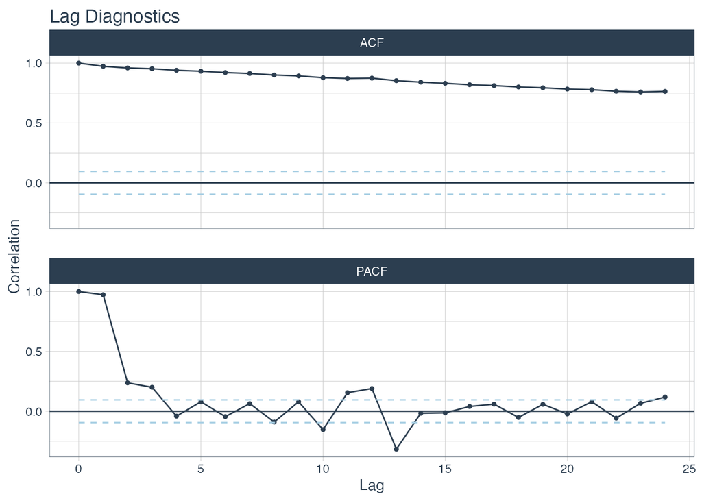

```r
monthly_retail_tbl %>%
  filter(Industry == Industries[[1]]) %>%
  plot_acf_diagnostics(Month,
                       Turnover,
                       .lags = "24 months",
                       .interactive = FALSE)
```

具体的なイメージはこちら。

```r
date <- seq(as.Date("2022-01-01"), as.Date("2022-01-30"), by = "day")
d <- tibble(date, value = 1:30)
d %>%
  tk_augment_lags(.value = value, .lags = c(12, 13)) %>%
  print(n = 30)
```

```
## # A tibble: 30 × 4
##    date       value value_lag12 value_lag13
##    <date>     <int>       <int>       <int>
##  1 2022-01-01     1          NA          NA
##  2 2022-01-02     2          NA          NA
##  3 2022-01-03     3          NA          NA
##  4 2022-01-04     4          NA          NA
##  5 2022-01-05     5          NA          NA
##  6 2022-01-06     6          NA          NA
##  7 2022-01-07     7          NA          NA
##  8 2022-01-08     8          NA          NA
##  9 2022-01-09     9          NA          NA
## 10 2022-01-10    10          NA          NA
## 11 2022-01-11    11          NA          NA
## 12 2022-01-12    12          NA          NA
```

[output cut: 18 more lines]

`Adjusted R-squared`は0.9237となっており、0.9037より微増したことがわかる。

```r
monthly_retail_tbl %>%
  filter(Industry == Industries[[1]]) %>%
  mutate(Turnover =  log1p(x = Turnover)) %>%
  mutate(Turnover =  standardize_vec(Turnover)) %>%
  tk_augment_timeseries_signature(.date_var = Month) %>%
  select(-diff, -matches("(.xts$)|(.iso$)|(hour)|(minute)|(second)|(day)|(week)|(am.pm)")) %>%
  dummy_cols(select_columns = c("month.lbl")) %>%
  select(-month.lbl) %>%
  mutate(index.num = normalize_vec(x = index.num)) %>%
  mutate(year = normalize_vec(x = year)) %>%
  tk_augment_fourier(.date_var = Month, .periods = 12, .K = 1) %>%
  tk_augment_lags(.value = Turnover, .lags = c(12, 13)) %>%
  plot_time_series_regression(.date_var = Month,
                              .formula = Turnover ~ as.numeric(Month) +
                                index.num + year + half + quarter + month +
                                month.lbl_January + month.lbl_February + month.lbl_March + month.lbl_April +
                                month.lbl_May + month.lbl_June + month.lbl_July + month.lbl_August +
                                month.lbl_September + month.lbl_October + month.lbl_November + month.lbl_December +
                                Month_sin12_K1 + Month_cos12_K1 +
                                Turnover_lag12 + Turnover_lag13,
                              .show_summary = TRUE)
```

```
##
## Call:
## stats::lm(formula = .formula, data = df)
##
## Residuals:
##      Min       1Q   Median       3Q      Max
## -0.79554 -0.14124 -0.00007  0.17381  0.61169
##
## Coefficients: (5 not defined because of singularities)
##                       Estimate Std. Error t value Pr(>|t|)
## (Intercept)         266.848010 197.170496   1.353    0.177
## as.numeric(Month)    -0.061529   0.045314  -1.358    0.175
## index.num                   NA         NA      NA       NA
## year                810.581465 595.830984   1.360    0.174
## half                  0.045880   0.117210   0.391    0.696
## quarter              -0.006946   0.170880  -0.041    0.968
## month                 1.892157   1.360976   1.390    0.165
## month.lbl_January     0.029223   0.178609   0.164    0.870
## month.lbl_February    0.099294   0.134229   0.740    0.460
## month.lbl_March       0.049029   0.104032   0.471    0.638
## month.lbl_April       0.025292   0.147450   0.172    0.864
## month.lbl_May         0.017459   0.100264   0.174    0.862
## month.lbl_June              NA         NA      NA       NA
## month.lbl_July       -0.045562   0.166993  -0.273    0.785
## month.lbl_August     -0.018226   0.098958  -0.184    0.854
## month.lbl_September         NA         NA      NA       NA
## month.lbl_October     0.001329   0.117352   0.011    0.991
## month.lbl_November          NA         NA      NA       NA
## month.lbl_December          NA         NA      NA       NA
## Month_sin12_K1       -0.009669   0.020029  -0.483    0.630
## Month_cos12_K1       -0.021998   0.020105  -1.094    0.275
## Turnover_lag12        0.426532   0.085389   4.995 8.72e-07 ***
## Turnover_lag13        0.063374   0.085430   0.742    0.459
## ---
## Signif. codes:  0 '***' 0.001 '**' 0.01 '*' 0.05 '.' 0.1 ' ' 1
##
## Residual standard error: 0.2617 on 410 degrees of freedom
##   (13 observations deleted due to missingness)
## Multiple R-squared:  0.9267, Adjusted R-squared:  0.9237
## F-statistic: 305.1 on 17 and 410 DF,  p-value: < 2.2e-16
```

[interactive chart not shown]

## ローリング特徴量

具体的なイメージはこちら。

```r
d %>%
  tk_augment_lags(.value = value, .lags = 12) %>%
  tk_augment_slidify(.value   = value_lag12,
                     .f       = ~ mean(.x, na.rm = TRUE),
                     .period  = c(3, 6, 9, 12),
                     .partial = TRUE,
                     .align   = "center") %>%
  print(n = 30)
```

```
## # A tibble: 30 × 7
##    date       value value_lag12 value_lag12_roll_3 value_lag12…¹ value…² value…³
##    <date>     <int>       <int>              <dbl>         <dbl>   <dbl>   <dbl>
##  1 2022-01-01     1          NA              NaN           NaN     NaN     NaN
##  2 2022-01-02     2          NA              NaN           NaN     NaN     NaN
##  3 2022-01-03     3          NA              NaN           NaN     NaN     NaN
##  4 2022-01-04     4          NA              NaN           NaN     NaN     NaN
##  5 2022-01-05     5          NA              NaN           NaN     NaN     NaN
##  6 2022-01-06     6          NA              NaN           NaN     NaN     NaN
##  7 2022-01-07     7          NA              NaN           NaN     NaN       1
##  8 2022-01-08     8          NA              NaN           NaN     NaN       1.5
##  9 2022-01-09     9          NA              NaN           NaN       1       2
## 10 2022-01-10    10          NA              NaN             1       1.5     2.5
## 11 2022-01-11    11          NA              NaN             1.5     2       3
## 12 2022-01-12    12          NA                1             2       2.5     3.5
```

[output cut: 20 more lines]

`Adjusted R-squared`は0.9481となっており、0.9237より微増したことがわかる。

```r
monthly_retail_tbl %>%
  filter(Industry == Industries[[1]]) %>%
  mutate(Turnover =  log1p(x = Turnover)) %>%
  mutate(Turnover =  standardize_vec(Turnover)) %>%
  tk_augment_timeseries_signature(.date_var = Month) %>%
  select(-diff, -matches("(.xts$)|(.iso$)|(hour)|(minute)|(second)|(day)|(week)|(am.pm)")) %>%
  dummy_cols(select_columns = c("month.lbl")) %>%
  select(-month.lbl) %>%
  mutate(index.num = normalize_vec(x = index.num)) %>%
  mutate(year = normalize_vec(x = year)) %>%
  tk_augment_fourier(.date_var = Month, .periods = 12, .K = 1) %>%
  tk_augment_lags(.value = Turnover, .lags = c(12, 13)) %>%
  tk_augment_slidify(.value   = c(Turnover_lag12, Turnover_lag13),
                     .f       = ~ mean(.x, na.rm = TRUE),
                     .period  = c(3, 6, 9, 12),
                     .partial = TRUE,
                     .align   = "center") %>%
  plot_time_series_regression(.date_var = Month,
                              .formula = Turnover ~ as.numeric(Month) +
                                index.num + year + half + quarter + month +
                                month.lbl_January + month.lbl_February + month.lbl_March + month.lbl_April +
                                month.lbl_May + month.lbl_June + month.lbl_July + month.lbl_August +
                                month.lbl_September + month.lbl_October + month.lbl_November + month.lbl_December +
                                Month_sin12_K1 + Month_cos12_K1 +
                                Turnover_lag12 + Turnover_lag12_roll_3  + Turnover_lag12_roll_6  + Turnover_lag12_roll_9 + Turnover_lag12_roll_12 +
                                Turnover_lag13 + Turnover_lag13_roll_3  + Turnover_lag13_roll_6  + Turnover_lag13_roll_9 + Turnover_lag13_roll_12,
                              .show_summary = TRUE)
```

```
##
## Call:
## stats::lm(formula = .formula, data = df)
##
## Residuals:
##      Min       1Q   Median       3Q      Max
## -0.65228 -0.12624 -0.00067  0.13133  0.78657
##
## Coefficients: (5 not defined because of singularities)
##                         Estimate Std. Error t value Pr(>|t|)
## (Intercept)             95.30640  163.30413   0.584  0.55981
## as.numeric(Month)       -0.02211    0.03753  -0.589  0.55606
## index.num                     NA         NA      NA       NA
## year                   291.82727  493.48550   0.591  0.55461
## half                     0.14258    0.11774   1.211  0.22661
## quarter                 -0.16283    0.18058  -0.902  0.36775
## month                    0.75295    1.12805   0.667  0.50485
## month.lbl_January        0.20144    0.18917   1.065  0.28758
## month.lbl_February       0.18250    0.13264   1.376  0.16961
## month.lbl_March          0.16548    0.10107   1.637  0.10235
## month.lbl_April          0.14551    0.15349   0.948  0.34368
## month.lbl_May            0.10645    0.10276   1.036  0.30086
## month.lbl_June                NA         NA      NA       NA
## month.lbl_July           0.05333    0.16037   0.333  0.73963
## month.lbl_August         0.05699    0.09385   0.607  0.54407
## month.lbl_September           NA         NA      NA       NA
## month.lbl_October        0.12642    0.11781   1.073  0.28388
## month.lbl_November            NA         NA      NA       NA
## month.lbl_December            NA         NA      NA       NA
## Month_sin12_K1          -0.05217    0.01766  -2.953  0.00333 **
## Month_cos12_K1          -0.05522    0.01798  -3.071  0.00228 **
## Turnover_lag12           0.15671    0.19215   0.816  0.41521
## Turnover_lag12_roll_3    0.20053    0.38534   0.520  0.60307
## Turnover_lag12_roll_6    0.36903    0.43344   0.851  0.39505
## Turnover_lag12_roll_9   -0.79671    0.74807  -1.065  0.28750
## Turnover_lag12_roll_12   4.55934    0.58574   7.784 6.01e-14 ***
## Turnover_lag13           0.07664    0.19488   0.393  0.69434
## Turnover_lag13_roll_3   -0.17368    0.34252  -0.507  0.61239
## Turnover_lag13_roll_6   -0.43496    0.56519  -0.770  0.44199
## Turnover_lag13_roll_9   -1.43135    0.60602  -2.362  0.01866 *
## Turnover_lag13_roll_12  -1.87214    0.73649  -2.542  0.01140 *
## ---
## Signif. codes:  0 '***' 0.001 '**' 0.01 '*' 0.05 '.' 0.1 ' ' 1
##
## Residual standard error: 0.2159 on 402 degrees of freedom
##   (13 observations deleted due to missingness)
## Multiple R-squared:  0.9511, Adjusted R-squared:  0.9481
## F-statistic: 312.9 on 25 and 402 DF,  p-value: < 2.2e-16
```

[interactive chart not shown]

## 参考文献

- [Time Series Forecasting Lab (Part 1) - Introduction to Feature Engineering](https://blog.bguarisma.com/time-series-forecasting-lab-part-1-introduction-to-feature-engineering)